# Face Impression Multivariate Analysis

얼굴 인상 평가 데이터의 잠재 구조와 탐색적 군집

stonetiger95

2026-09-21

# 1 프로젝트 개요

이 프로젝트는 Oosterhof & Todorov (2008)의 얼굴 인상 연구에서 사용된 사회적 평정 데이터를 바탕으로, **PCA, Factor Analysis, Clustering**에서 공통된 구조가 나타나는지 비교한다. 기존 연구의 2차원 모델을 그대로 복제했다고 주장하지 않고, 동일한 얼굴 자극 평정에서 구조가 다른 다변량 방법에서도 어떻게 나타나는지를 탐색한다.

분석 단위는 참가자 개인이 아니라 **여러 참가자의 평정을 평균한 얼굴 자극 66개**다. 따라서 결과는 자극 수준의 평균 인상 구조이며, 개인의 성격이나 실제 능력을 설명하지 않는다.

# 2 데이터와 분석 질문

```r
raw <- read_xls(data_path)

trait_names <- c(
  "attractive", "caring", "aggressive", "mean", "intelligent",
  "confident", "emotionally stable", "trustworthy", "responsible",
  "sociable", "weird", "unhappy", "dominant", "threatening"
)
required_columns <- c("Karolinska Label", "Todorov Label", "gender", trait_names)

stopifnot(all(required_columns %in% names(raw)))
stopifnot(nrow(raw) == 66L)

ID <- raw[["Todorov Label"]]
gender <- factor(raw$gender)
X <- as.data.frame(raw[trait_names])
rownames(X) <- ID
```

분석 질문은 다음과 같다.

1. 14개 사회적 인상 평정은 몇 개의 주요 차원으로 요약되는가?
2. PCA와 PCFA·MLFA에서 유사한 구조가 나타나는가?
3. 얼굴 자극들이 주요 차원상에서 탐색적 군집을 형성하는가?

# 3 EDA와 다변량 정규성

```r
descriptive <- data.frame(
  Mean = sapply(X, mean),
  SD = sapply(X, sd),
  Min = sapply(X, min),
  Max = sapply(X, max)
)
kable(round(descriptive, 3), caption = "Descriptive statistics for 66 averaged face stimuli")
```

Descriptive statistics for 66 averaged face stimuli

|  | Mean | SD | Min | Max |
| --- | --- | --- | --- | --- |
| attractive | 0.000 | 0.707 | -1.19 | 1.48 |
| caring | 0.000 | 0.630 | -1.35 | 1.23 |
| aggressive | 0.000 | 0.640 | -1.16 | 1.48 |
| mean | 0.000 | 0.664 | -1.25 | 1.82 |
| intelligent | 0.000 | 0.537 | -1.71 | 0.88 |
| confident | 0.000 | 0.574 | -1.49 | 1.07 |
| emotionally stable | 0.000 | 0.630 | -1.67 | 1.23 |
| trustworthy | 0.000 | 0.646 | -1.56 | 1.35 |
| responsible | 0.000 | 0.630 | -1.55 | 1.20 |
| sociable | -0.001 | 0.627 | -1.43 | 1.09 |
| weird | 0.000 | 0.691 | -1.22 | 1.86 |
| unhappy | 0.000 | 0.581 | -1.02 | 1.51 |
| dominant | 0.000 | 0.575 | -1.33 | 1.18 |
| threatening | 0.000 | 0.630 | -1.27 | 1.76 |

각 변수의 평균은 0에 가깝다. 참가자별 z-score를 얼굴 자극별로 평균했기 때문에 표준편차는 1보다 작고 변수마다 다르다.

```r
R <- cor(X)

png("figures/correlation_matrix.png", width = 1800, height = 1500, res = 190)
par(mar = c(9, 9, 3, 2))
display_names <- gsub("emotionally stable", "emot_stable", colnames(X), fixed = TRUE)
palette <- colorRampPalette(c("#234f9b", "#f7f7f7", "#b4202a"))(101)
image(
  1:ncol(R), 1:nrow(R), t(R[nrow(R):1, ]),
  col = palette, zlim = c(-1, 1), axes = FALSE,
  xlab = "", ylab = "", main = "Correlation matrix of 14 trait ratings"
)
axis(1, at = 1:ncol(R), labels = display_names, las = 2, cex.axis = 0.75)
axis(2, at = 1:nrow(R), labels = rev(display_names), las = 2, cex.axis = 0.75)
for (i in seq_len(nrow(R))) {
  for (j in seq_len(ncol(R))) {
    text(j, nrow(R) - i + 1, sprintf("%.2f", R[i, j]), cex = 0.48)
  }
}
box()
dev.off()
```

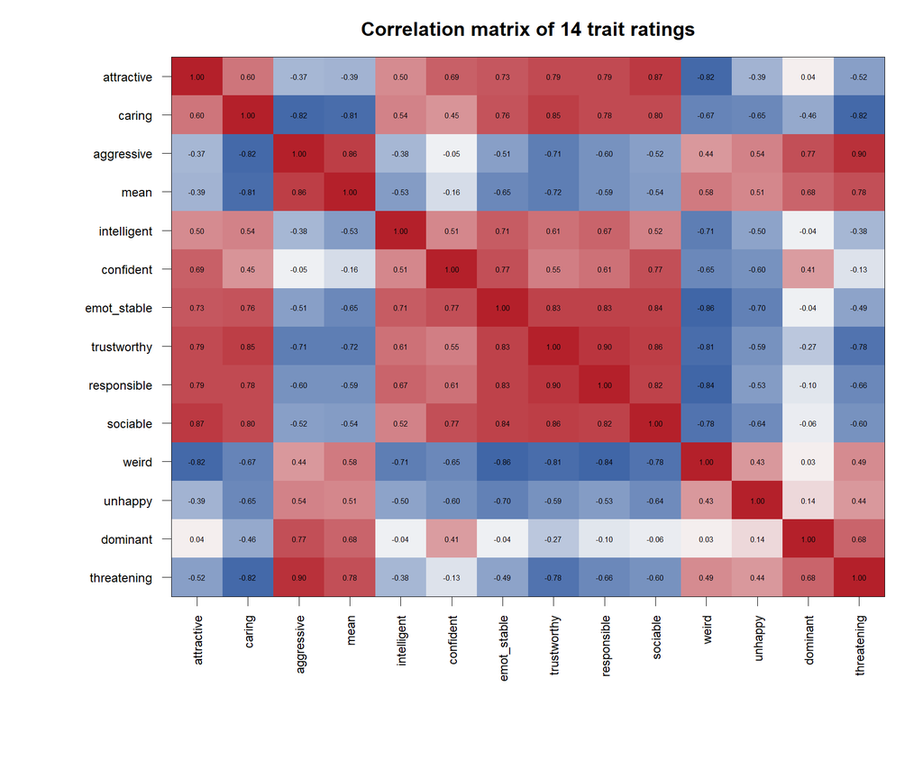

```r
include_graphics(file.path(project_root, "figures", "correlation_matrix.png"))
```

긍정적·친사회적 평정끼리, 그리고 공격성·위협성·심술궂음 평정끼리 높은 상관이 나타난다. 이는 차원 축소를 적용할 실질적 근거가 된다.

## 3.1 Mardia test

```r
Z <- scale(X)
n <- nrow(Z)
p <- ncol(Z)

D2 <- mahalanobis(X, colMeans(X), cov(X))
kurtosis_z <- (mean(D2^2) - p * (p + 2)) / sqrt(8 * p * (p + 2) / n)
kurtosis_p <- 2 * pnorm(abs(kurtosis_z), lower.tail = FALSE)

G <- Z %*% solve(cov(Z)) %*% t(Z)
b1p <- mean(G^3)
skew_stat <- n * b1p / 6
skew_df <- p * (p + 1) * (p + 2) / 6
skew_p <- pchisq(skew_stat, skew_df, lower.tail = FALSE)

mardia_table <- data.frame(
  Test = c("Mardia skewness", "Mardia kurtosis"),
  Statistic = c(skew_stat, kurtosis_z),
  df = c(skew_df, NA),
  p_value = c(skew_p, kurtosis_p)
)
kable(mardia_table, digits = 4)
```

| Test | Statistic | df | p_value |
| --- | --- | --- | --- |
| Mardia skewness | 544.1993 | 560 | 0.6761 |
| Mardia kurtosis | -1.3230 | NA | 0.1858 |

Skewness와 kurtosis 검정에서 다변량 정규성을 기각할 충분한 근거는 없었다. 그러나 큰 p-value는 정규성이 입증됐다는 뜻이 아니며, 66개 자극이라는 작은 표본에서 검정력이 제한될 수 있다.

# 4 Principal Component Analysis

원 과제와 동일하게 표준편차가 서로 다른 14개 평균 평정에 공분산 기반 `prcomp()`를 적용했다. 이 선택은 원 분석을 보존하기 위한 것이며, correlation-based PCFA와 설명량이 조금 다른 이유이기도 하다.

```r
pca <- prcomp(X)
pca_importance <- summary(pca)$importance
kable(round(pca_importance[, 1:5], 3), caption = "PCA explained variance")
```

PCA explained variance

|  | PC1 | PC2 | PC3 | PC4 | PC5 |
| --- | --- | --- | --- | --- | --- |
| Standard deviation | 1.885 | 0.998 | 0.552 | 0.484 | 0.330 |
| Proportion of Variance | 0.645 | 0.181 | 0.055 | 0.043 | 0.020 |
| Cumulative Proportion | 0.645 | 0.825 | 0.881 | 0.923 | 0.943 |

PC1은 64.5%, PC2는 18.1%를 설명하며, 두 성분의 누적 설명력은 82.5%다. PC1은 긍정적·친사회적 평정과 부정적·위협적 평정을 대조한다. PC2에는 dominant가 가장 크게 기여하며 aggressive, threatening, confident도 관련된다. 주성분 부호는 임의적이므로 방향보다 변수들의 상대적 배치가 중요하다.

```r
png("figures/pca_results.png", width = 1900, height = 900, res = 180)
par(mfrow = c(1, 2), mar = c(5, 5, 4, 2))

variance_pct <- 100 * pca_importance[2, ]
plot(
  variance_pct, type = "b", pch = 19, col = "#245a9a",
  xlab = "Principal component", ylab = "Variance explained (%)",
  main = "Scree plot", xaxt = "n"
)
axis(1, at = seq_along(variance_pct))
abline(v = 2.5, lty = 3, col = "gray50")

loads <- pca$rotation[, 1:2]
y_pos <- rev(seq_len(nrow(loads)))
plot(
  loads[, 1], y_pos, pch = 19, col = "#245a9a",
  xlim = range(loads) * 1.08, ylim = c(0.5, nrow(loads) + 0.5),
  xlab = "Loading", ylab = "", yaxt = "n",
  main = "PCA loadings"
)
points(loads[, 2], y_pos, pch = 17, col = "#b4202a")
axis(2, at = y_pos,
     labels = gsub("emotionally stable", "emot_stable", rownames(loads), fixed = TRUE),
     las = 2, cex.axis = 0.65)
abline(v = 0, lty = 3, col = "gray70")
legend("bottomright", legend = c("PC1", "PC2"),
       col = c("#245a9a", "#b4202a"), pch = c(19, 17), bty = "n")

dev.off()
```

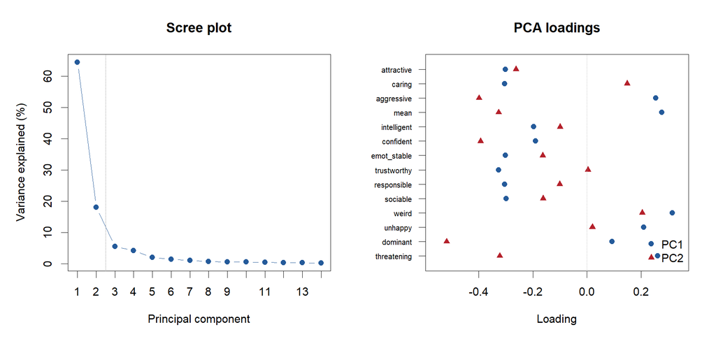

```r
include_graphics(file.path(project_root, "figures", "pca_results.png"))
```

# 5 Factor Analysis

## 5.1 PCFA

PCFA는 상관행렬의 고유분해로 계산했다. 첫 두 성분은 표준화된 전체 분산의 81.8%를 설명한다.

```r
eig <- eigen(R)
pcfa_loadings <- sweep(
  eig$vectors[, 1:2, drop = FALSE],
  2,
  sqrt(eig$values[1:2]),
  "*"
)
rownames(pcfa_loadings) <- colnames(X)
colnames(pcfa_loadings) <- c("PCFA 1", "PCFA 2")
kable(round(pcfa_loadings, 3), caption = "Unrotated PCFA loadings")
```

Unrotated PCFA loadings

|  | PCFA 1 | PCFA 2 |
| --- | --- | --- |
| attractive | -0.794 | -0.345 |
| caring | -0.914 | 0.230 |
| aggressive | 0.751 | -0.620 |
| mean | 0.785 | -0.484 |
| intelligent | -0.703 | -0.199 |
| confident | -0.629 | -0.696 |
| emotionally stable | -0.906 | -0.268 |
| trustworthy | -0.948 | 0.011 |
| responsible | -0.909 | -0.154 |
| sociable | -0.898 | -0.252 |
| weird | 0.853 | 0.281 |
| unhappy | 0.697 | 0.064 |
| dominant | 0.303 | -0.908 |
| threatening | 0.777 | -0.518 |

## 5.2 MLFA with Varimax rotation

```r
mlfa <- factanal(Z, factors = 2, rotation = "varimax", scores = "regression")
mlfa_loadings <- unclass(mlfa$loadings)
kable(round(mlfa_loadings, 3), caption = "Varimax-rotated MLFA loadings")
```

Varimax-rotated MLFA loadings

|  | Factor1 | Factor2 |
| --- | --- | --- |
| attractive | 0.848 | -0.145 |
| caring | 0.654 | -0.673 |
| aggressive | -0.300 | 0.928 |
| mean | -0.398 | 0.799 |
| intelligent | 0.645 | -0.207 |
| confident | 0.891 | 0.239 |
| emotionally stable | 0.891 | -0.258 |
| trustworthy | 0.797 | -0.514 |
| responsible | 0.842 | -0.365 |
| sociable | 0.896 | -0.273 |
| weird | -0.848 | 0.220 |
| unhappy | -0.596 | 0.327 |
| dominant | 0.224 | 0.905 |
| threatening | -0.387 | 0.845 |

```r
ss_loadings <- colSums(mlfa_loadings^2)
mlfa_variance <- sum(ss_loadings) / ncol(X)
```

Factor 1은 attractive, confident, emotionally stable, trustworthy, responsible, sociable과 정적으로, weird와 부적으로 관련된다. Factor 2는 aggressive, mean, dominant, threatening과 정적으로 관련된다. 두 요인의 SS loadings는 전체 변수 분산의 79.4%에 해당한다.

그러나 exact-fit test는 χ²(64) = 257.88, p < .001이다. 따라서 2-factor model은 해석상 유용한 요약이지만 상관구조를 충분히 재현하는 완전한 모형이라고 단정할 수 없다.

```r
plot_loading_matrix <- function(M, title) {
  pal <- colorRampPalette(c("#234f9b", "#f7f7f7", "#b4202a"))(101)
  image(
    1:ncol(M), 1:nrow(M), t(M[nrow(M):1, , drop = FALSE]),
    col = pal, zlim = c(-1, 1), axes = FALSE,
    xlab = "", ylab = "", main = title
  )
  axis(1, at = 1:ncol(M), labels = colnames(M), cex.axis = 0.85)
  axis(2, at = 1:nrow(M), labels = rev(gsub("emotionally stable", "emot_stable", rownames(M), fixed = TRUE)),
       las = 2, cex.axis = 0.65)
  for (i in seq_len(nrow(M))) {
    for (j in seq_len(ncol(M))) {
      text(j, nrow(M) - i + 1, sprintf("%.2f", M[i, j]), cex = 0.65)
    }
  }
  box()
}

png("figures/factor_analysis.png", width = 1800, height = 1250, res = 180)
par(mfrow = c(1, 2), mar = c(5, 8, 4, 2))
plot_loading_matrix(pcfa_loadings, "PCFA loadings")
plot_loading_matrix(mlfa_loadings, "MLFA loadings (Varimax)")
dev.off()
```

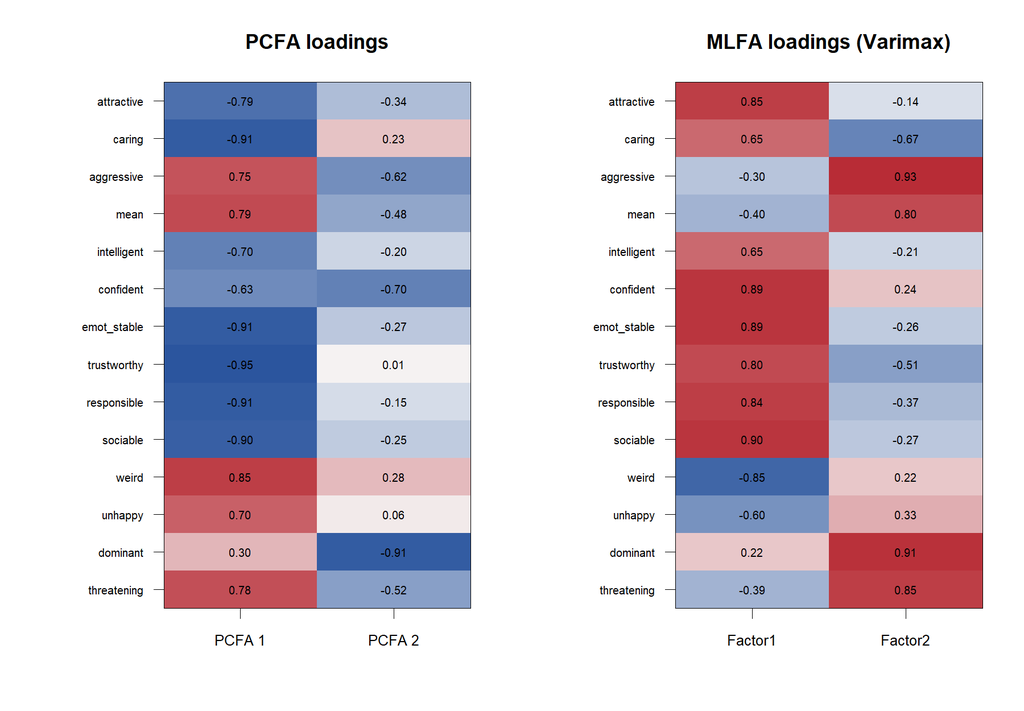

```r
include_graphics(file.path(project_root, "figures", "factor_analysis.png"))
```

# 6 Cluster Analysis

## 6.1 Hierarchical clustering and number of clusters

원 분석은 Euclidean distance에서 single, complete, average, Ward linkage를 비교했다. R의 과거 부분 일치 `method = "ward"`를 명시적인 `method = "ward.D"`로 기록했다. 이후 군집 수는 원 분석과 동일한 `NbClust(..., method = "ward.D2", index = "all")` 다수결을 사용했다.

```r
distance_matrix <- dist(X, method = "euclidean")
hclust_models <- list(
  single = hclust(distance_matrix, method = "single"),
  complete = hclust(distance_matrix, method = "complete"),
  average = hclust(distance_matrix, method = "average"),
  ward = hclust(distance_matrix, method = "ward.D")
)

nb_plot <- tempfile(fileext = ".pdf")
pdf(nb_plot)
nb_output <- capture.output(
  nb <- NbClust(
    X,
    distance = "euclidean",
    min.nc = 2,
    max.nc = 10,
    method = "ward.D2",
    index = "all"
  )
)
dev.off()
```

```r
unlink(nb_plot)

nb_votes <- sort(table(nb$Best.nc[1, ]), decreasing = TRUE)
kable(
  data.frame(clusters = names(nb_votes), votes = as.integer(nb_votes)),
  row.names = FALSE,
  caption = "NbClust recommendations"
)
```

NbClust recommendations

| clusters | votes |
| --- | --- |
| 3 | 9 |
| 2 | 7 |
| 0 | 2 |
| 4 | 2 |
| 5 | 2 |
| 10 | 2 |
| 1 | 1 |
| 7 | 1 |

다수결에서는 3개 군집이 가장 많은 지지를 받았다. 다만 이는 군집 안정성 검증이 아니며, 2개 군집을 지지한 지표도 많았다.

## 6.2 Reproducible K-means

```r
set.seed(2025)
km <- kmeans(Z, centers = 3)

cluster_centers <- aggregate(X, by = list(cluster = km$cluster), FUN = mean)
cluster_sizes <- as.integer(table(km$cluster))
kable(round(cluster_centers, 3), caption = "K-means centers on the original rating scale")
```

K-means centers on the original rating scale

| cluster | attractive | caring | aggressive | mean | intelligent | confident | emotionally stable | trustworthy | responsible | sociable | weird | unhappy | dominant | threatening |
| --- | --- | --- | --- | --- | --- | --- | --- | --- | --- | --- | --- | --- | --- | --- |
| 1 | 0.716 | 0.452 | -0.241 | -0.324 | 0.337 | 0.523 | 0.578 | 0.570 | 0.596 | 0.633 | -0.621 | -0.360 | 0.106 | -0.302 |
| 2 | -0.692 | -0.814 | 0.716 | 0.756 | -0.471 | -0.385 | -0.744 | -0.798 | -0.754 | -0.696 | 0.818 | 0.482 | 0.315 | 0.701 |
| 3 | -0.257 | 0.105 | -0.257 | -0.199 | -0.019 | -0.272 | -0.076 | -0.028 | -0.087 | -0.168 | 0.066 | 0.034 | -0.332 | -0.183 |

재현성을 위해 seed를 고정했다. 군집 크기는 25, 17, 24이다. Cluster 1은 상대적으로 긍정적·친사회적, Cluster 2는 부정적·위협적, Cluster 3은 평균에 가깝고 dominance가 낮은 패턴이다. silhouette 또는 bootstrap stability 검증이 없으므로 이 명칭은 확정된 유형이 아닌 탐색적 요약이다.

```r
cluster_colors <- c("#2c7fb8", "#d95f0e", "#31a354")
cluster_names <- c("Positive / prosocial", "Negative / threatening", "Middle / low dominance")

png("figures/cluster_pca.png", width = 1500, height = 1100, res = 180)
plot(
  pca$x[, 1:2],
  col = cluster_colors[km$cluster], pch = 19, cex = 1.25,
  xlab = sprintf("PC1 (%.1f%%)", 100 * pca_importance[2, 1]),
  ylab = sprintf("PC2 (%.1f%%)", 100 * pca_importance[2, 2]),
  main = "Exploratory K-means clusters in PCA space"
)
abline(h = 0, v = 0, lty = 3, col = "gray70")
legend(
  "topright", legend = paste0("Cluster ", 1:3, ": ", cluster_names),
  col = cluster_colors, pch = 19, bty = "o", bg = "white",
  box.col = "gray80", cex = 0.78
)
dev.off()
```

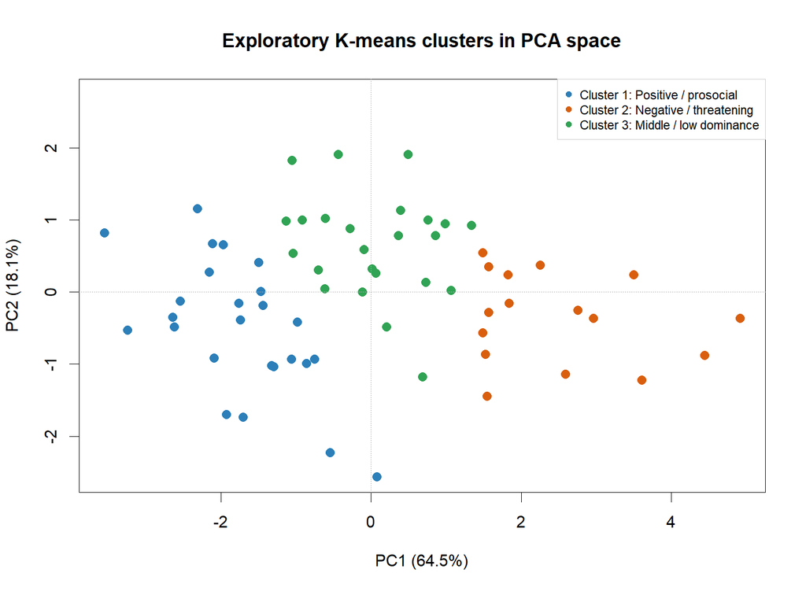

```r
include_graphics(file.path(project_root, "figures", "cluster_pca.png"))
```

## 6.3 군집과 자극 성별

```r
gender_table <- table(cluster = km$cluster, gender = gender)
gender_test <- chisq.test(gender_table)
kable(gender_table, caption = "Cluster by stimulus gender")
```

Cluster by stimulus gender

| female | male |
| --- | --- |
| 15 | 10 |
| 7 | 10 |
| 11 | 13 |

고정 seed 군집과 자극 성별의 연관은 유의하지 않았다(χ²(2) = 1.70, p = 0.428). 이 분석은 같은 표본으로 군집을 만든 뒤 관계를 살핀 탐색적 보조 결과다. 성별 집단의 일반적 심리 차이나 고정관념의 증거로 확대하지 않는다.

# 7 결론

PCA, PCFA, MLFA는 세부 회전과 입력 행렬의 차이에도 불구하고 긍정성·친사회성과 지배성·위협성에 관련된 큰 구조를 공유했다. K-means는 이 공간에서 세 개의 상대적 패턴을 만들었지만, 안정성 검증이 없어 탐색적 군집으로만 해석해야 한다.

이 결과는 기존 연구가 제안한 face evaluation의 valence/trustworthiness와 dominance 차원과 유사하다. 동시에 2-factor MLFA exact-fit 부족, 요인 수 선택 방법의 제한, 평균화된 66개 자극이라는 분석 단위 때문에 동일한 구조가 확정됐다고 말할 수는 없다.

# 8 Limitations

- 얼굴 자극 66개라는 작은 분석 단위
- 참가자 수준 자료가 아닌 평균 평정값 사용
- 원 분석을 보존한 공분산 기반 PCA이므로 표준편차가 큰 평정 변수가 더 큰 영향을 받을 수 있음
- scree plot과 설명력 중심의 요인 수 결정
- 2-factor MLFA exact-fit test의 유의한 결과
- silhouette·bootstrap stability 검증 부재
- 같은 자료에서 군집 생성 후 성별 관계 탐색
- 얼굴 인상을 실제 성격 또는 일반 인구로 확장할 수 없음

# 10 References

1. Oosterhof, N. N., & Todorov, A. (2008). The functional basis of face evaluation. *Proceedings of the National Academy of Sciences, 105*(32), 11087–11092. https://doi.org/10.1073/pnas.0805664105
2. Lundqvist, D., Flykt, A., & Öhman, A. (1998). *The Karolinska Directed Emotional Faces (KDEF)*.
3. Todorov, A., & Oh, D. (2021). The structure and perceptual basis of social judgments from faces. *Advances in Experimental Social Psychology, 63*, 189–246.